# Tidytext

Joanna Deszcz, Julia Gnatek, Julia Kwapień, Zuzanna Piekarczyk

06.05.2023

**Przydatne linki:**  
https://github.com/dgrtwo/tidy-text-mining/blob/master/index.Rmd  
https://www.tidytextmining.com/tidytext.html  
https://bookdown.org/Maxine/tidy-text-mining/tidy-text-format.html  
https://github.com/rstudio/rmarkdown

# Biblioteki

```r
#install.packages("rmarkdown")
#install.packages("dplyr")
#install.packages("tidytext")
#install.packages("stringr")
#install.packages("udpipe")
#install.packages("textstem")
#install.packages("tm")
#install.packages("topicmodels")
#install.packages("quanteda")
#install.packages("ggplot2")
#install.packages("tidyr")
#install.packages("stringr")
#install.packages("rmdformats")
```

# Dane

W projekcie zostały wykorzystane dane z polskimi przysłowiami, które zostały udostępnione w trakcie laboratioriów. Dzięki ponownemu wykorzystaniu znanego zbioru możliwa będzie lepsza ocena wyników uzyskanych podczas pracy z pakietem **tidytext** w porównaniu z metodami zaprezentowanymi na zajęciach. Dane zawierają 10 rekordów, gdzie każdy rekord to jedno przysłowie.

## Wczytanie danych

Dane zostały wczytane przy użyciu wektora danych do zmiennej *text*.

```r
text <- c("Jesień tego nie zrodzi, czego wiosna nie zasiała","Czego wiosna nie zasiała – jesień nie urodzi","Św. Bartłomiej pogodny, jesień pogodna","Bartłomiej zwiastuje, jaka jesień następuje, i czy w przyszłym latku dożyjesz dostatku","Bartłomiej zwiastuje, jaka jesień następuje","Bartłomieja cały wrzesień naśladuje, i z nim jesień","Bartłomieja świętego dzień w jakiej zostaje porze, taką jesień bez ochyby daje","Jaki Bartek niesie dzień, taka będzie i jesień","Jaki Bartek niesie dzień, taka będzie i jesień","Jaki Bartek, taki wrzesień, jaki Marcin, taka zima")
```

## Czyszczenie tekstu

Wszystkie te operacje służą do usunięcia niepotrzebnych znaków i wyrazów z tekstu, które mogą zakłócać analizę tekstu lub utrudniać jego przetwarzanie. Funkcja zwraca wyczyszczony tekst - zmienna *clean_text*.

```r
clean <- function(text){

  require(stringr)
  tekst_tenmp <- str_replace_all(text, "\\s{2,}", " ") %>%
    str_replace_all("[:cntrl:]", " ") %>%
    tolower() %>%
    str_remove_all("[:punct:]") %>%
    str_remove_all("\\d") %>%
    str_trim()
}
clean_text <- clean(text)
clean_text
```

```
##  [1] "jesień tego nie zrodzi czego wiosna nie zasiała"
##  [2] "czego wiosna nie zasiała  jesień nie urodzi"
##  [3] "św bartłomiej pogodny jesień pogodna"
##  [4] "bartłomiej zwiastuje jaka jesień następuje i czy w przyszłym latku dożyjesz dostatku"
##  [5] "bartłomiej zwiastuje jaka jesień następuje"
##  [6] "bartłomieja cały wrzesień naśladuje i z nim jesień"
##  [7] "bartłomieja świętego dzień w jakiej zostaje porze taką jesień bez ochyby daje"
##  [8] "jaki bartek niesie dzień taka będzie i jesień"
##  [9] "jaki bartek niesie dzień taka będzie i jesień"
## [10] "jaki bartek taki wrzesień jaki marcin taka zima"
```

## Stworzenie tabeli zgodnie z ideą tidytext

Kod tworzy dataframe o nazwie *text_df* z dwoma kolumnami: kolumna “line” zawiera numery linii tekstu, natomiast kolumna “text” zawiera wyczyszczony tekst.

Funkcja *tibble* pochodzi z pakietu **tibble** i jest używana do tworzenia tzw. “tidy data frames”, czyli data frame’ów, w których każda kolumna odpowiada jednej zmiennej, a każdy wiersz odpowiada jednej obserwacji. W tym przypadku każda obserwacja to jedna linia tekstu, a każda zmienna to numer linii i tekst.

```r
text_df <- tibble(line = 1:length(clean_text), text=clean_text)
text_df
```

```
## # A tibble: 10 × 2
##     line text
##    <int> <chr>
##  1     1 jesień tego nie zrodzi czego wiosna nie zasiała
##  2     2 czego wiosna nie zasiała  jesień nie urodzi
##  3     3 św bartłomiej pogodny jesień pogodna
##  4     4 bartłomiej zwiastuje jaka jesień następuje i czy w przyszłym latku doż…
##  5     5 bartłomiej zwiastuje jaka jesień następuje
##  6     6 bartłomieja cały wrzesień naśladuje i z nim jesień
##  7     7 bartłomieja świętego dzień w jakiej zostaje porze taką jesień bez ochy…
##  8     8 jaki bartek niesie dzień taka będzie i jesień
##  9     9 jaki bartek niesie dzień taka będzie i jesień
## 10    10 jaki bartek taki wrzesień jaki marcin taka zima
```

## Tokenizacja

W kolejnym kroku zostaje wykonana tokenizacja zgodnie z ideą tidytext, czyli podział przysłów na słowa/tokeny.

Funkcja *unnest_tokens* z biblioteki **tidytext** dzieli tekst na pojedyncze słowa, usuwając jednocześnie wszelkie białe znaki i znaki interpunkcyjne, a następnie umieszcza każde słowo w osobnym wierszu.

Funkcja ta jest przydatna w analizie tekstu, ponieważ umożliwia łatwe zliczanie wystąpień poszczególnych słów i ich analizę. Wynikowy dataframe o nazwie *text_tok* zawiera dwie kolumny: *line*, zawierającą numer linii tekstu, i *word*, zawierającą pojedyncze słowa z tej linii.

```r
text_tok <- text_df %>%
  unnest_tokens(word, text)
```

## Stopwords

Następnie zostaje stworzona lista “stopwords” (słów-kluczy, które mają zostać usunięte z tekstu), która zostaje przekonwetowana na format *tibble* charakterystyczny dla pakietu *tidytext*.

Działanie kodu można podzielić na trzy etapy:

1. Utworzenie listy “stopwords” zawierającej słowa, które mają zostać usunięte z tekstu. Lista ta jest utworzona ręcznie i zawiera słowa takie jak “tak”, “to”, “i”, “w” itp., które są bardzo często występującymi słowami i nie niosą dużo znaczenia w kontekście analizy tekstu.
2. Kod używa funkcji **stri_encode** z pakietu *stringi*, aby przekonwertować listę “stopwords” do formatu UTF-8.
3. Ostatecznie kod tworzy *tibble* z kolumną **word**, zawierającą listę słów z listy **stopwords**.

```r
stopwords <- c('tak', 'to', 'tego', 'czego', 'jaka', 'taka', 'i', 'czy', 'w', 'z', 'nim', 'jakiej', 'taką', 'jaki', 'takąć', 'takąż', 'taki', 'św')

stopwords <- stringi::stri_encode(stopwords, to = "UTF-8")

stopwords <- tibble(word=stopwords)
```

Po stworzeniu listy stopwords wykorzystana zostaje funkcja *anti_join()* do wyeliminowania stopwords z tekstu. Operacja ta polega na zwróceniu tylko tych wierszy z ramki *text_tok*, dla których nie ma dopasowania z ramką *stopwords* w kolumnie *word*. W tym przypadku chodzi o usunięcie słów, które znajdują się na liście stopwords i są nieistotne z perspektywy analizy tekstu.

```r
text_stop <- anti_join(text_tok, stopwords, by = join_by(word == word))
text_stop
```

```
## # A tibble: 56 × 2
##     line word
##    <int> <chr>
##  1     1 jesień
##  2     1 nie
##  3     1 zrodzi
##  4     1 wiosna
##  5     1 nie
##  6     1 zasiała
##  7     2 wiosna
##  8     2 nie
##  9     2 zasiała
## 10     2 jesień
## # ℹ 46 more rows
```

## Lematyzacja

Lematyzacja to proces sprowadzenia słowa do jego podstawowej formy, zwanej lematem. Celem lematyzacji jest ujednolicenie form słów w tekście, tak aby różne odmiany tego samego słowa były traktowane jako jedno słowo. Lematyzacja jest podobna do stemmingu, ale zamiast obcinania końcówek słów, lematyzacja korzysta z reguł gramatycznych danego języka, aby uzyskać lematy - w tym przypadku reguł języka polskiego.

```r
text_lem_stem <- text_stop %>%
  mutate(word_lemma = lemmatize_words(word, language = "polish"))
text_lem_stem
```

```
## # A tibble: 56 × 3
##     line word    word_lemma
##    <int> <chr>   <chr>
##  1     1 jesień  jesień
##  2     1 nie     nie
##  3     1 zrodzi  zrodzi
##  4     1 wiosna  wiosna
##  5     1 nie     nie
##  6     1 zasiała zasiała
##  7     2 wiosna  wiosna
##  8     2 nie     nie
##  9     2 zasiała zasiała
## 10     2 jesień  jesień
## # ℹ 46 more rows
```

Niestety jak można zauważyć R nie poradził sobie z lematyzacją w j. polskim i słowa pozostały w niezmienionej formie. Dlatego też zdecydowano się na dokonanie lematyzacji w oparciu o słownik wykorzystywany podczas zajęć.

W pierwszym kroku wczytany został uproszczony słownik z pliku *slownik.txt* do zmiennej *dictionary*. Dane przekształcono na typ tibble w celu zachowania spójności z pakietem **tidytext**. Dodatkowo dokonany zmiany nazwy drugiej kolumny na *word*.

Wykorzystano pakiet **dplyr** oraz funkcję *left_join()*, która po dopasowaniu zmiennej *word* w dataframe’ie *text_stop* ze wzorcem *word* w dataframe’ie *dictionary* zamieniała wartość na wzorzec z kolumny *V1*.

```r
dictionary <- read.csv2("slownik.txt", header=F, fileEncoding = "")

dictionary <- as_tibble(dictionary, rownames = NULL)

dictionary<- rename(dictionary, word = V2)

text_lem <- text_stop %>%
  left_join(dictionary, by = c("word" = "word")) %>%
  mutate(word = if_else(!is.na(V1), V1, word))
text_lem <- text_lem %>% select(line, word)
text_lem
```

```
## # A tibble: 56 × 2
##     line word
##    <int> <chr>
##  1     1 jesień
##  2     1 nie
##  3     1 zrodzić
##  4     1 wiosna
##  5     1 nie
##  6     1 zasiać
##  7     2 wiosna
##  8     2 nie
##  9     2 zasiać
## 10     2 jesień
## # ℹ 46 more rows
```

### Przygotowanie tabeli document-term

Ostatnim elementem etapu przygotowania danych było zliczenie ilości wystąpień poszczególnych termów w obrębie danego przysłowia przy użyciu funkcji *count()* z pakietu **dplyr**. W rezultacie powstał obiekt tibble o wymiarach 53x3. W podejściu tidy nie ma potrzeby tworzenia bag of words. W nomenklaturze tidytext obiekt ten można nazwać tabelą *document-term*, która posłuży do stworzenia m.in. *macierzy document-term* w kolejnych etapach projektu.

```r
text_lem <- text_lem %>%
  select(line,word) %>%
  count(line, word) %>%
  rename(count = n, word = word)
text_lem
```

```
## # A tibble: 53 × 3
##     line word    count
##    <int> <chr>   <int>
##  1     1 jesień      1
##  2     1 nie         2
##  3     1 wiosna      1
##  4     1 zasiać      1
##  5     1 zrodzić     1
##  6     2 jesień      1
##  7     2 nie         2
##  8     2 urodzić     1
##  9     2 wiosna      1
## 10     2 zasiać      1
## # ℹ 43 more rows
```

Tak przekształcone dane były gotowe do przeprowadzenia zaplanowanych analiz.

# Macierze document-term

Jedną z najczęstszych struktur, z którymi współpracują pakiety do text mining, jest macierz document-term (DTM). Jest to macierz, w której:

- każdy wiersz reprezentuje jeden dokument (w tym przypadku jedno przysłowie),
- każda kolumna reprezentuje jeden termin
- i każda wartość zawiera liczbę wystąpień tego terminu w tym dokumencie.

Ponieważ większość par dokumentu i terminu nie występuje (mają one wartość zero), DTM są zwykle implementowane jako macierze typu sparse (macierze rzadkie). Obiekty te można traktować tak, jakby były macierzami, ale są przechowywane w bardziej wydajnym formacie.

## Macierz document-term (DTM)

Do stworzenia macierzy document-term użyto funkcji *cast_dtm()* z pakietu **quanteda**. Jednak macierz DTM w podejściu tidy różni się od macierzy tworzonych w innych bibliotekach czy językach programowania. W tym przypadku w wyniku wykonania kodu otrzymujemy podsumowanie wyników, a nie samą macierz.

Można odczytać nastepujące wnioski:  
1. funkcja znalazła 10 dokumentów (przysłów), w których znajduje się 28 unikalnych termów (słów); 2. w macierzy występują 53 wpisy, co oznacza, że wiele kombinacji dokument-słowo jest pusta; 3. wartość rzadkości (sparsity) wynosi 81%, co oznacza, że większość kombinacji dokument-słowo nie występuje w danych; 4. najdłuższe słowo składa się z 10 liter.

Waga w macierzy została obliczona na podstawie liczby wystąpień danego słowa w danym dokumencie. Oznacza to, że waga danego słowa w danym dokumencie zależy od liczby jego wystąpień w tym dokumencie. Metoda wagowania ta nazywa się *term frequency (tf)* i jest jednym z kilku sposobów obliczania wag w macierzy dokument-słowo.

```r
dtm <- text_lem %>%
  cast_dtm(document = line, term = word, value = count)
dtm
```

```
## <<DocumentTermMatrix (documents: 10, terms: 28)>>
## Non-/sparse entries: 53/227
## Sparsity           : 81%
## Maximal term length: 10
## Weighting          : term frequency (tf)
```

## Macierz sparse document-term SDTM

W kolejnym kroku utworzono macierz rzadką (SDTM) przy użyciu funkcji *cast_sparse()* z pakietu **quanteda**, w której każdy wiersz odpowiada jednemu dokumentowi (przysłowiu), a każda kolumna reprezentuje dane słowo (token). Na przecięciach wierszy i kolumn wyliczone zostały liczebności tokenów w obrębie poszczególnych dokumentów.

Macierz typu sparse charakteryzuje się tym, że w miejscach, gdzie kombinacja dokument-słowo jest pusta, wyświetlana jest kropka zamiast zera i przypomina ona bardziej typową macierz DTM.

```r
dtm_sparse <- text_lem %>%
  cast_sparse(line, word, count)
dtm_sparse
```

```
## 10 x 28 sparse Matrix of class "dgCMatrix"
```

```
##   [[ suppressing 28 column names 'jesień', 'nie', 'wiosna' ... ]]
```

```
##
## 1  1 2 1 1 1 . . . . . . . . . . . . . . . . . . . . . . .
## 2  1 2 1 1 . 1 . . . . . . . . . . . . . . . . . . . . . .
## 3  1 . . . . . 1 2 . . . . . . . . . . . . . . . . . . . .
## 4  1 . . . . . 1 . 1 1 1 1 1 1 . . . . . . . . . . . . . .
## 5  1 . . . . . 1 . . . . 1 . 1 . . . . . . . . . . . . . .
## 6  1 . . . . . 1 . . . . . . . 1 1 1 . . . . . . . . . . .
## 7  1 . . . . . 1 . . . . . . . . . . 1 1 1 1 1 1 1 . . . .
## 8  1 . . . . . 1 . . . . . . . . . . . . 1 . . . . 1 1 . .
## 9  1 . . . . . 1 . . . . . . . . . . . . 1 . . . . 1 1 . .
## 10 . . . . . . 1 . . . . . . . . . 1 . . . . . . . . . 1 1
```

## Macierz document-feature (DFM)

Jednak typowym dla podejścia tidy są macierze document-feature (DFM), które również należą do pakietu **quanteda**. Funkcja cast_dfm() przekształca obiekt tibble w macierz DFM, która wygląda podobnie jak macierze DTM tworzone w innych pakietach/językach programowania. Wynikiem jest tabela podobna do macierzy SDTM z tą różnicą, że macierz posiada nagłówki, a w miejscach, gdzie kombinacja dokument-feature jest pusta, wyświetlane jest zero.

```r
dfm <- text_lem %>%
  cast_dfm(document = line, term = word, value = count)
dfm
```

```
## Document-feature matrix of: 10 documents, 28 features (81.07% sparse) and 0 docvars.
##     features
## docs jesień nie wiosna zasiać zrodzić urodzić bartłomiej pogodny dostatek dożyć
##    1      1   2      1      1       1       0          0       0        0     0
##    2      1   2      1      1       0       1          0       0        0     0
##    3      1   0      0      0       0       0          1       2        0     0
##    4      1   0      0      0       0       0          1       0        1     1
##    5      1   0      0      0       0       0          1       0        0     0
##    6      1   0      0      0       0       0          1       0        0     0
## [ reached max_ndoc ... 4 more documents, reached max_nfeat ... 18 more features ]
```

## Macierz feature-document (FDM)

Za pomocą funkcji **t()** oraz **as.matrix()** wygenerowano również macierz FDM (feature-document), czyli transponowaną macierz DFM.

```r
fdm <- t(as.matrix(dfm))
fdm
```

```
##             docs
## features     1 2 3 4 5 6 7 8 9 10
##   jesień     1 1 1 1 1 1 1 1 1  0
##   nie        2 2 0 0 0 0 0 0 0  0
##   wiosna     1 1 0 0 0 0 0 0 0  0
##   zasiać     1 1 0 0 0 0 0 0 0  0
##   zrodzić    1 0 0 0 0 0 0 0 0  0
##   urodzić    0 1 0 0 0 0 0 0 0  0
##   bartłomiej 0 0 1 1 1 1 1 1 1  1
##   pogodny    0 0 2 0 0 0 0 0 0  0
##   dostatek   0 0 0 1 0 0 0 0 0  0
##   dożyć      0 0 0 1 0 0 0 0 0  0
##   lat        0 0 0 1 0 0 0 0 0  0
##   następować 0 0 0 1 1 0 0 0 0  0
##   przyszły   0 0 0 1 0 0 0 0 0  0
##   zwiastować 0 0 0 1 1 0 0 0 0  0
##   cały       0 0 0 0 0 1 0 0 0  0
##   naśladować 0 0 0 0 0 1 0 0 0  0
##   wrzesień   0 0 0 0 0 1 0 0 0  1
##   bez        0 0 0 0 0 0 1 0 0  0
##   dać        0 0 0 0 0 0 1 0 0  0
##   dzień      0 0 0 0 0 0 1 1 1  0
##   ochyby     0 0 0 0 0 0 1 0 0  0
##   pora       0 0 0 0 0 0 1 0 0  0
##   zostać     0 0 0 0 0 0 1 0 0  0
##   święty     0 0 0 0 0 0 1 0 0  0
##   być        0 0 0 0 0 0 0 1 1  0
##   nieść      0 0 0 0 0 0 0 1 1  0
##   marcin     0 0 0 0 0 0 0 0 0  1
##   zima       0 0 0 0 0 0 0 0 0  1
```

## Binarna macierz feature-document

Macierz FDM zamieniono na macierz binarną. W wyniku tej sekwencji kodu, zmienna **binary_fdm** będzie zawierała macierz binarną, w której każdy element będzie przyjmował wartość 1, jeśli odpowiadający mu element w macierzy FDM jest większy niż 0, a w przeciwnym przypadku będzie miał wartość 0. Do przeprowadzenia konwersji użyto funkcji **apply()**. W tym przypadku **MARGIN = c(1,2)** oznacza, że funkcja **FUN** będzie zastosowana do każdego elementu macierzy FDM.

```r
binary_fdm <- apply(fdm, MARGIN = c(1,2), FUN = function(x) ifelse(x > 0, 1, 0))
binary_fdm
```

```
##             docs
## features     1 2 3 4 5 6 7 8 9 10
##   jesień     1 1 1 1 1 1 1 1 1  0
##   nie        1 1 0 0 0 0 0 0 0  0
##   wiosna     1 1 0 0 0 0 0 0 0  0
##   zasiać     1 1 0 0 0 0 0 0 0  0
##   zrodzić    1 0 0 0 0 0 0 0 0  0
##   urodzić    0 1 0 0 0 0 0 0 0  0
##   bartłomiej 0 0 1 1 1 1 1 1 1  1
##   pogodny    0 0 1 0 0 0 0 0 0  0
##   dostatek   0 0 0 1 0 0 0 0 0  0
##   dożyć      0 0 0 1 0 0 0 0 0  0
##   lat        0 0 0 1 0 0 0 0 0  0
##   następować 0 0 0 1 1 0 0 0 0  0
##   przyszły   0 0 0 1 0 0 0 0 0  0
##   zwiastować 0 0 0 1 1 0 0 0 0  0
##   cały       0 0 0 0 0 1 0 0 0  0
##   naśladować 0 0 0 0 0 1 0 0 0  0
##   wrzesień   0 0 0 0 0 1 0 0 0  1
##   bez        0 0 0 0 0 0 1 0 0  0
##   dać        0 0 0 0 0 0 1 0 0  0
##   dzień      0 0 0 0 0 0 1 1 1  0
##   ochyby     0 0 0 0 0 0 1 0 0  0
##   pora       0 0 0 0 0 0 1 0 0  0
##   zostać     0 0 0 0 0 0 1 0 0  0
##   święty     0 0 0 0 0 0 1 0 0  0
##   być        0 0 0 0 0 0 0 1 1  0
##   nieść      0 0 0 0 0 0 0 1 1  0
##   marcin     0 0 0 0 0 0 0 0 0  1
##   zima       0 0 0 0 0 0 0 0 0  1
```

## Logarytmiczna macierz feature-document

Kod tworzy nową macierz **log_fdm**, która jest logarytmem naturalnym z wartości macierzy FDM zwiększonymi o 1.

Następnie, wywołanie funkcji **log()** z argumentem **fdm + 1** oblicza logarytm naturalny z wartości w macierzy FDM z dodaną wartością 1.

W przypadku analizy tekstu, zastosowanie logarytmu naturalnego zwiększa wagi rzadko występujących cech, co może poprawić wyniki analizy. Dodanie wartości 1 jest wykorzystywane, aby uniknąć obliczenia logarytmu z wartości równej 0.

Ostatecznie, zmienna log_fdm przechowuje macierz o tych samych wymiarach co macierz fdm, ale z wartościami zmienionymi na logarytmy.

```r
log_fdm <- log(fdm + 1)
log_fdm
```

```
##             docs
## features             1         2         3         4         5         6
##   jesień     0.6931472 0.6931472 0.6931472 0.6931472 0.6931472 0.6931472
##   nie        1.0986123 1.0986123 0.0000000 0.0000000 0.0000000 0.0000000
##   wiosna     0.6931472 0.6931472 0.0000000 0.0000000 0.0000000 0.0000000
##   zasiać     0.6931472 0.6931472 0.0000000 0.0000000 0.0000000 0.0000000
##   zrodzić    0.6931472 0.0000000 0.0000000 0.0000000 0.0000000 0.0000000
##   urodzić    0.0000000 0.6931472 0.0000000 0.0000000 0.0000000 0.0000000
##   bartłomiej 0.0000000 0.0000000 0.6931472 0.6931472 0.6931472 0.6931472
##   pogodny    0.0000000 0.0000000 1.0986123 0.0000000 0.0000000 0.0000000
##   dostatek   0.0000000 0.0000000 0.0000000 0.6931472 0.0000000 0.0000000
##   dożyć      0.0000000 0.0000000 0.0000000 0.6931472 0.0000000 0.0000000
##   lat        0.0000000 0.0000000 0.0000000 0.6931472 0.0000000 0.0000000
##   następować 0.0000000 0.0000000 0.0000000 0.6931472 0.6931472 0.0000000
##   przyszły   0.0000000 0.0000000 0.0000000 0.6931472 0.0000000 0.0000000
##   zwiastować 0.0000000 0.0000000 0.0000000 0.6931472 0.6931472 0.0000000
##   cały       0.0000000 0.0000000 0.0000000 0.0000000 0.0000000 0.6931472
##   naśladować 0.0000000 0.0000000 0.0000000 0.0000000 0.0000000 0.6931472
##   wrzesień   0.0000000 0.0000000 0.0000000 0.0000000 0.0000000 0.6931472
##   bez        0.0000000 0.0000000 0.0000000 0.0000000 0.0000000 0.0000000
##   dać        0.0000000 0.0000000 0.0000000 0.0000000 0.0000000 0.0000000
##   dzień      0.0000000 0.0000000 0.0000000 0.0000000 0.0000000 0.0000000
##   ochyby     0.0000000 0.0000000 0.0000000 0.0000000 0.0000000 0.0000000
##   pora       0.0000000 0.0000000 0.0000000 0.0000000 0.0000000 0.0000000
##   zostać     0.0000000 0.0000000 0.0000000 0.0000000 0.0000000 0.0000000
##   święty     0.0000000 0.0000000 0.0000000 0.0000000 0.0000000 0.0000000
##   być        0.0000000 0.0000000 0.0000000 0.0000000 0.0000000 0.0000000
##   nieść      0.0000000 0.0000000 0.0000000 0.0000000 0.0000000 0.0000000
##   marcin     0.0000000 0.0000000 0.0000000 0.0000000 0.0000000 0.0000000
##   zima       0.0000000 0.0000000 0.0000000 0.0000000 0.0000000 0.0000000
##             docs
## features             7         8         9        10
##   jesień     0.6931472 0.6931472 0.6931472 0.0000000
##   nie        0.0000000 0.0000000 0.0000000 0.0000000
##   wiosna     0.0000000 0.0000000 0.0000000 0.0000000
##   zasiać     0.0000000 0.0000000 0.0000000 0.0000000
##   zrodzić    0.0000000 0.0000000 0.0000000 0.0000000
##   urodzić    0.0000000 0.0000000 0.0000000 0.0000000
##   bartłomiej 0.6931472 0.6931472 0.6931472 0.6931472
##   pogodny    0.0000000 0.0000000 0.0000000 0.0000000
##   dostatek   0.0000000 0.0000000 0.0000000 0.0000000
##   dożyć      0.0000000 0.0000000 0.0000000 0.0000000
##   lat        0.0000000 0.0000000 0.0000000 0.0000000
##   następować 0.0000000 0.0000000 0.0000000 0.0000000
##   przyszły   0.0000000 0.0000000 0.0000000 0.0000000
##   zwiastować 0.0000000 0.0000000 0.0000000 0.0000000
##   cały       0.0000000 0.0000000 0.0000000 0.0000000
##   naśladować 0.0000000 0.0000000 0.0000000 0.0000000
##   wrzesień   0.0000000 0.0000000 0.0000000 0.6931472
##   bez        0.6931472 0.0000000 0.0000000 0.0000000
##   dać        0.6931472 0.0000000 0.0000000 0.0000000
##   dzień      0.6931472 0.6931472 0.6931472 0.0000000
##   ochyby     0.6931472 0.0000000 0.0000000 0.0000000
##   pora       0.6931472 0.0000000 0.0000000 0.0000000
##   zostać     0.6931472 0.0000000 0.0000000 0.0000000
##   święty     0.6931472 0.0000000 0.0000000 0.0000000
##   być        0.0000000 0.6931472 0.6931472 0.0000000
##   nieść      0.0000000 0.6931472 0.6931472 0.0000000
##   marcin     0.0000000 0.0000000 0.0000000 0.6931472
##   zima       0.0000000 0.0000000 0.0000000 0.6931472
```

## Macierz TF-IDF

Aby przekształcić macierz FDM na macierz TF-IDF (Term Frequency-Inverse Document Frequency), należy pomnożyć każdy element macierzy TF przez wagę IDF dla danego termu, która wyraża się wzorem:

inline equation: $IDF(t) = log(N/DF(t))$

gdzie: *N* - liczba wszystkich dokumentów *df(t)* - liczba dokumentów zawierających term t.

W wyniku tej sekwencji kodu, zmienna **tfidf_matrix** będzie zawierała macierz TF-IDF, w której każdy element będzie wynikiem pomnożenia odpowiadającego mu elementu w macierzy TF przez wagę IDF dla danego termu.

Ta operacja pozwala na wyodrębnienie najistotniejszych słów (termów) w danym dokumencie, ponieważ słowa występujące często w jednym dokumencie, ale rzadko w innych, będą miały wyższą wagę TF-IDF.

```r
tf_matrix <- t(apply(fdm, 1, function(x) x/sum(x))) # macierz TF
idf_weights <- log(nrow(fdm)/rowSums(fdm > 0)) # wektor wag IDF
tfidf_matrix <- tf_matrix * idf_weights # macierz TF-IDF
tfidf_matrix
```

```
##             docs
## features             1         2         3         4         5         6
##   jesień     0.1261089 0.1261089 0.1261089 0.1261089 0.1261089 0.1261089
##   nie        1.3195287 1.3195287 0.0000000 0.0000000 0.0000000 0.0000000
##   wiosna     1.3195287 1.3195287 0.0000000 0.0000000 0.0000000 0.0000000
##   zasiać     1.3195287 1.3195287 0.0000000 0.0000000 0.0000000 0.0000000
##   zrodzić    3.3322045 0.0000000 0.0000000 0.0000000 0.0000000 0.0000000
##   urodzić    0.0000000 3.3322045 0.0000000 0.0000000 0.0000000 0.0000000
##   bartłomiej 0.0000000 0.0000000 0.1565954 0.1565954 0.1565954 0.1565954
##   pogodny    0.0000000 0.0000000 3.3322045 0.0000000 0.0000000 0.0000000
##   dostatek   0.0000000 0.0000000 0.0000000 3.3322045 0.0000000 0.0000000
##   dożyć      0.0000000 0.0000000 0.0000000 3.3322045 0.0000000 0.0000000
##   lat        0.0000000 0.0000000 0.0000000 3.3322045 0.0000000 0.0000000
##   następować 0.0000000 0.0000000 0.0000000 1.3195287 1.3195287 0.0000000
##   przyszły   0.0000000 0.0000000 0.0000000 3.3322045 0.0000000 0.0000000
##   zwiastować 0.0000000 0.0000000 0.0000000 1.3195287 1.3195287 0.0000000
##   cały       0.0000000 0.0000000 0.0000000 0.0000000 0.0000000 3.3322045
##   naśladować 0.0000000 0.0000000 0.0000000 0.0000000 0.0000000 3.3322045
##   wrzesień   0.0000000 0.0000000 0.0000000 0.0000000 0.0000000 1.3195287
##   bez        0.0000000 0.0000000 0.0000000 0.0000000 0.0000000 0.0000000
##   dać        0.0000000 0.0000000 0.0000000 0.0000000 0.0000000 0.0000000
##   dzień      0.0000000 0.0000000 0.0000000 0.0000000 0.0000000 0.0000000
##   ochyby     0.0000000 0.0000000 0.0000000 0.0000000 0.0000000 0.0000000
##   pora       0.0000000 0.0000000 0.0000000 0.0000000 0.0000000 0.0000000
##   zostać     0.0000000 0.0000000 0.0000000 0.0000000 0.0000000 0.0000000
##   święty     0.0000000 0.0000000 0.0000000 0.0000000 0.0000000 0.0000000
##   być        0.0000000 0.0000000 0.0000000 0.0000000 0.0000000 0.0000000
##   nieść      0.0000000 0.0000000 0.0000000 0.0000000 0.0000000 0.0000000
##   marcin     0.0000000 0.0000000 0.0000000 0.0000000 0.0000000 0.0000000
##   zima       0.0000000 0.0000000 0.0000000 0.0000000 0.0000000 0.0000000
##             docs
## features             7         8         9        10
##   jesień     0.1261089 0.1261089 0.1261089 0.0000000
##   nie        0.0000000 0.0000000 0.0000000 0.0000000
##   wiosna     0.0000000 0.0000000 0.0000000 0.0000000
##   zasiać     0.0000000 0.0000000 0.0000000 0.0000000
##   zrodzić    0.0000000 0.0000000 0.0000000 0.0000000
##   urodzić    0.0000000 0.0000000 0.0000000 0.0000000
##   bartłomiej 0.1565954 0.1565954 0.1565954 0.1565954
##   pogodny    0.0000000 0.0000000 0.0000000 0.0000000
##   dostatek   0.0000000 0.0000000 0.0000000 0.0000000
##   dożyć      0.0000000 0.0000000 0.0000000 0.0000000
##   lat        0.0000000 0.0000000 0.0000000 0.0000000
##   następować 0.0000000 0.0000000 0.0000000 0.0000000
##   przyszły   0.0000000 0.0000000 0.0000000 0.0000000
##   zwiastować 0.0000000 0.0000000 0.0000000 0.0000000
##   cały       0.0000000 0.0000000 0.0000000 0.0000000
##   naśladować 0.0000000 0.0000000 0.0000000 0.0000000
##   wrzesień   0.0000000 0.0000000 0.0000000 1.3195287
##   bez        3.3322045 0.0000000 0.0000000 0.0000000
##   dać        3.3322045 0.0000000 0.0000000 0.0000000
##   dzień      0.7445307 0.7445307 0.7445307 0.0000000
##   ochyby     3.3322045 0.0000000 0.0000000 0.0000000
##   pora       3.3322045 0.0000000 0.0000000 0.0000000
##   zostać     3.3322045 0.0000000 0.0000000 0.0000000
##   święty     3.3322045 0.0000000 0.0000000 0.0000000
##   być        0.0000000 1.3195287 1.3195287 0.0000000
##   nieść      0.0000000 1.3195287 1.3195287 0.0000000
##   marcin     0.0000000 0.0000000 0.0000000 3.3322045
##   zima       0.0000000 0.0000000 0.0000000 3.3322045
```

# Wizualizacja

## Liczba wystąpień poszczególnych termów

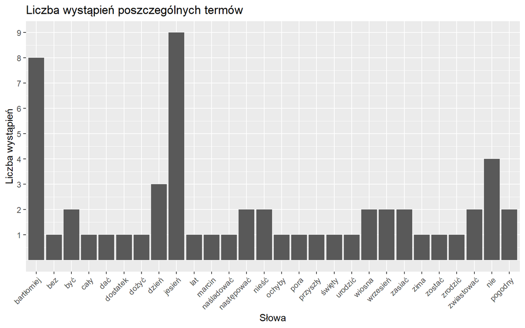

```r
ggplot(text_lem , aes(x = reorder(word, count), y = count)) +
  geom_bar(stat = "identity") +
  theme(axis.text.x = element_text(angle = 45, hjust = 1)) +
  labs(x = "Słowa", y = "Liczba wystąpień") +
  ggtitle("Liczba wystąpień poszczególnych termów") +
  scale_y_continuous(breaks = c(1,2,3,4,5,6,7,8,9,10))
```